# Analysis for RNA-seq and ATAC-seq data in Amiri et al 2026

## 8.Save zld results

```r
write_xlsx(list("res.zldKD.ac.rna"=as.data.frame(res.zld.ac.rna),
           "res.res.zldKD.zldnoKD.rna" =as.data.frame(res.zld.noKD.rna),
           "res.zldnoKD.ac.rna"=as.data.frame(res.zldnoKD.ac.rna)), "../zldKD/zld_degs_all.xlsx")
```

```r
write_xlsx(list("res.zld.ac.atac" = as.data.frame(res.zld.ac.atac),
                "res.zld.ac.rna" =  as.data.frame(res.zld.ac.rna),
                "zld.daps.motif" = as.data.frame(zld.daps.motif),
                "zld.daps.change.genomic.feature" = as.data.frame(zld.daps.change.genomic.feature),
                "zld.daps.c.gf.m" = as.data.frame(zld.daps.c.gf.m),
                "zld.daps.dynamic.peaks" = as.data.frame(zld.daps.dynamic.peaks),
                "zld.degs.mz" = as.data.frame(zld.degs.mz)),
                "../zldKD/zld-all-results.xlsx")
```

```r
library(org.Dm.eg.db)
```

```r
blast.table<-read.csv("../Annotation_Data/Clogmia.blast.csv")
# Assuming your DESeq2 results data frame is called 'res'
# and the FlyBase IDs are either the row names or in a column called 'flybase.id'

# Add a new column with the gene symbols
blast.table$gene_name <- unname(mapIds(
  x = org.Dm.eg.db,
  keys = blast.table$flybase.id,     # The column containing FBgn IDs
  column = "SYMBOL",         # What you want to get out (gene name)
  keytype = "FLYBASE",       # What you are putting in
  multiVals = "first"        # If a gene has multiple names, just take the first one
))
write.csv(blast.table, "../Annotation_Data/Clogmia.blast.csv", row.names = F)
```

# Section 4 Gene loci visualization

### plotting functions

function for smoothing big wig/wiggle files for plotting

```r
wigsmooth = function(x){
    a = score(x)
    b = zoo::rollmean(zoo::as.zoo(a), 10)
    c = rep(0, length(a))
    c[zoo::index(b)] = b
    score(x) = c
    return(x)
}
```

Gvizzer funciton to plot ATAC and RNA-seq data

```r
gvizzer = function(ROI, # region of interest
                   view.width = NULL, # resize, or NULL chooses the size of the ROI
                   counts = bw, # GRangesList with counts
                   nplots = 5, # how many of the GRangesList elements to plot?
                   title = "", # text appended to the plotted genome coordinates title
                   shifter = 0, # how much to nudge the ROI to the right or left
                   txstack = "dense", # dense or full display of the gene region track
                   scalebar = 1000, # scale bar length in bp
                   trackcols = c(
                       "darkorchid4",
                       "darkorchid4",
                       "cornflowerblue",
                       "cornflowerblue",
                       "grey"
                   ), # a vector of colors for each plotted element in 'counts'
                   plotType = c(rep("histogram", 4), 'histogram'), # plot type
                   ymin = c(0, 0, 0, 0, -1.25), # y-axis minimum value per plot
                   ymax = c(40, 40, 40, 40, 1.25) # y-axis maximum value per plot
) {

    # note, in this version, the nplots value should be equal to the number of
    # specified colors, and the number of elements in the ymin and ymax vectors.
    require(Gviz)
    require(GenomicRanges)
    require(BSgenome.Calbipunctata.Cantata.uni4000)

    oregion = GRanges(ROI)

    if(is.null(view.width)){view.width = width(oregion)}

    chr = as.character(seqnames(oregion))
    region = resize(oregion, width = view.width, fix = "center")
    start(region) = start(region) + shifter
    end(region) = end(region) + shifter

    from = as.numeric(start(region))
    to = as.numeric(end(region))

    title = paste0(title, ": ", region)
    options(ucscChromosomeNames=FALSE) # required, otherwise Gviz will expect usc formatted chr names ie chr1 etc
    grtrack = GeneRegionTrack(
        calbi.txdb,
        genome = "ca6",
        from = from,
        to = to,
        chromosome = chr,
        stacking = txstack
        )

    gtr = GenomeAxisTrack(scale = scalebar)

    dts = list()

    for(i in 1 : nplots)
    {
        dts[[i]] = DataTrack(
            counts[[i]],
            name = names(counts)[i],
            type = plotType[i],
            ylim=c(ymin[i], ymax[i]),
            col.histogram = rgb(t(col2rgb(trackcols[i])/255), alpha = 0), # make the border transparent.
            fill.histogram = trackcols[i],
            col.mountain = trackcols[i],
            fill.mountain = rep(trackcols[i], 2)
            )
    }
    # note that specifying colors for different kinds of plot types does not throw an error
    # this means it is easy to write a general for-loop to generate the data tracks
    # and still be able to choose different plot types in the options for the function.

    plotTracks(
        trackList = c(list(gtr), dts[c(1:nplots)], list(grtrack)),
        from = from,
        to = to,
        chromosome = chr,
        main = title,
        cex.main = 1
    )
}
```

### Load opa kd ATAC and RNA big wig/wiggle data

opaKD NC12 RNA merged

```r
ac.nc12.rna.bw <- GRanges(import("../Processed_Data/Wiggles/opa/RNA/NC12/ac-nc12-rna-merged.bw", format = 'bw'))
ac.nc12.rna.bw <- wigsmooth(ac.nc12.rna.bw)

dsred.nc12.rna.bw <- GRanges(import("../Processed_Data/Wiggles/opa/RNA/NC12/dsred-nc12-rna-merged.bw", format = 'bw'))
dsred.nc12.rna.bw <- wigsmooth(dsred.nc12.rna.bw)

opa.nc12.rna.bw <- GRanges(import("../Processed_Data/Wiggles/opa/RNA/NC12/opa-nc12-rna-merged.bw", format = 'bw'))
opa.nc12.rna.bw <- wigsmooth(opa.nc12.rna.bw)

noKD.nc12.rna.bw <- GRanges(import("../Processed_Data/Wiggles/opa/RNA/NC12/noKD-nc12-rna-merged.bw", format = 'bw'))

opakd.nc12.groups.rna.bw <- GRangesList("AC" = ac.nc12.rna.bw,
                                  "IC" = dsred.nc12.rna.bw,
                                  "opaKD" = opa.nc12.rna.bw)
```

NC12 ATAC merged

```r
ac.nc12.atac.bw <- GRanges(import("../Processed_Data/Wiggles/opa/ATAC/NC12/ac-nc12-atac-merged.bw", format = 'bw'))
ac.nc12.atac.bw <- wigsmooth(ac.nc12.atac.bw)

dsred.nc12.atac.bw <- GRanges(import("../Processed_Data/Wiggles/opa/ATAC/NC12/dsred-nc12-atac-merged.bw", format = 'bw'))
dsred.nc12.atac.bw <- wigsmooth(dsred.nc12.atac.bw)

opa.nc12.atac.bw <- GRanges(import("../Processed_Data/Wiggles/opa/ATAC/NC12/opa-nc12-atac-merged.bw", format = 'bw'))
opa.nc12.atac.bw <- wigsmooth(opa.nc12.atac.bw)

noKD.nc12.atac.bw <- GRanges(import("../Processed_Data/Wiggles/opa/ATAC/NC12/noKD-nc12-atac-merged.bw", format = 'bw'))

opakd.nc12.groups.atac.bw <- GRangesList("AC" = ac.nc12.atac.bw,
                                  "IC" = dsred.nc12.atac.bw,
                                  "opaKD" = opa.nc12.atac.bw)
```

*NC13*

NC13 RNA merged

```r
ac.nc13.rna.bw <- GRanges(import("../Processed_Data/Wiggles/opa/RNA/NC13/ac-nc13-rna-merged.bw", format = 'bw'))
ac.nc13.rna.bw <- wigsmooth(ac.nc13.rna.bw)

dsred.nc13.rna.bw <- GRanges(import("../Processed_Data/Wiggles/opa/RNA/NC13/dsred-nc13-rna-merged.bw", format = 'bw'))
dsred.nc13.rna.bw <- wigsmooth(dsred.nc13.rna.bw)

opa.nc13.rna.bw <- GRanges(import("../Processed_Data/Wiggles/opa/RNA/NC13/opa-nc13-rna-merged.bw", format = 'bw'))
opa.nc13.rna.bw <- wigsmooth(opa.nc13.rna.bw)

noKD.nc13.rna.bw<-GRanges(import("../Processed_Data/Wiggles/opa/RNA/NC13/noKD-nc13-rna-merged.bw"))
noKD.nc13.rna.bw <- wigsmooth(noKD.nc13.rna.bw)


opakd.nc13.groups.rna.bw <- GRangesList("AC" = ac.nc13.rna.bw,
                                  "IC" = dsred.nc13.rna.bw,
                                  "opanoKD" = noKD.nc13.rna.bw,
                                   "opaKD"= opa.nc13.rna.bw)
```

NC13 ATAC merged

```r
ac.nc13.atac.bw <- GRanges(import("../Processed_Data/Wiggles/opa/ATAC/NC13/ac-nc13-atac-merged.bw", format = 'bw'))
ac.nc13.atac.bw <- wigsmooth(ac.nc13.atac.bw)

dsred.nc13.atac.bw <- GRanges(import("../Processed_Data/Wiggles/opa/ATAC/NC13/dsred-nc13-atac-merged.bw", format = 'bw'))
dsred.nc13.atac.bw <- wigsmooth(dsred.nc13.atac.bw)

opa.nc13.atac.bw <- GRanges(import("../Processed_Data/Wiggles/opa/ATAC/NC13/opa-nc13-atac-merged.bw", format = 'bw'))
opa.nc13.atac.bw <- wigsmooth(opa.nc13.atac.bw)

noKD.nc13.atac.bw<-GRanges(import("../Processed_Data/Wiggles/opa/ATAC/NC13/noKD-nc13-atac-merged.bw"))
noKD.nc13.atac.bw <- wigsmooth(noKD.nc13.atac.bw)

opakd.nc13.groups.atac.bw <- GRangesList("AC" = ac.nc13.atac.bw,
                                  "IC" = dsred.nc13.atac.bw,
                                  "opanoKD"= noKD.nc13.atac.bw,
                                  "opaKD" = opa.nc13.atac.bw)
```

### hbn locus NC12

```r
hbn.locus <- calbi.genes[names(calbi.genes) == "evm.TU.scaffold_4.1647"]
hbn.locus <- resize(hbn.locus,width = 18000,fix = "center")
hbn.locus
```

```
## GRanges object with 1 range and 1 metadata column:
##                            seqnames            ranges strand |
##                               <Rle>         <IRanges>  <Rle> |
##   evm.TU.scaffold_4.1647 scaffold_4 18065399-18083398      - |
##                                         gene_id
##                                     <character>
##   evm.TU.scaffold_4.1647 evm.TU.scaffold_4.1647
##   -------
##   seqinfo: 308 sequences from ca6 genome
```

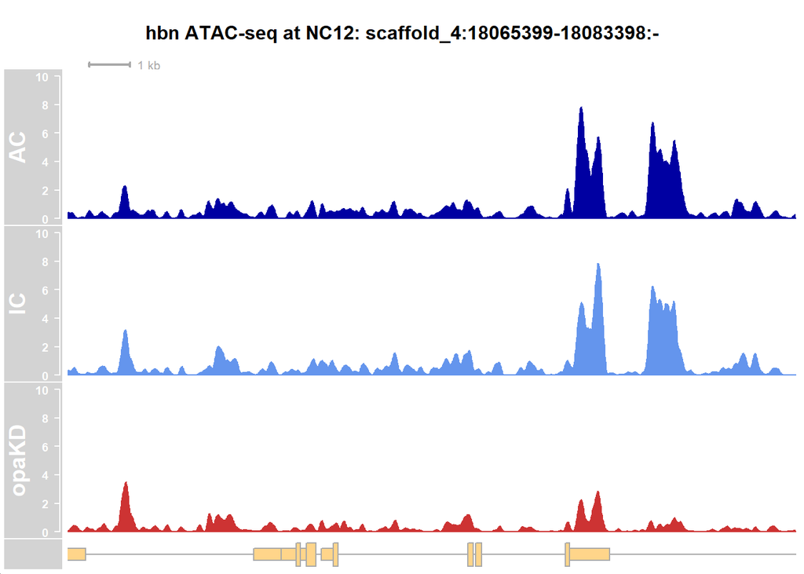

```r
#pdf(file = "./Gviz/hbn-nc12-atac-merged_10cpm.pdf", width = 8,height = 4.5)

gvizzer(ROI= hbn.locus,
        counts = opakd.nc12.groups.atac.bw,
        view.width = width(hbn.locus),
        nplots = 3,
        shifter = 0,
        title = 'hbn ATAC-seq at NC12',
        txstack = "dense",
        scalebar = 1000 ,
        trackcols = c(rep("#0000a2", 1), rep("cornflowerblue", 1), rep("brown3", 1)),
        plotType = rep("polygon", 4),
        ymin = rep(0, 3),
        ymax = rep(10, 3)
       )
```

```r
#dev.off()
```

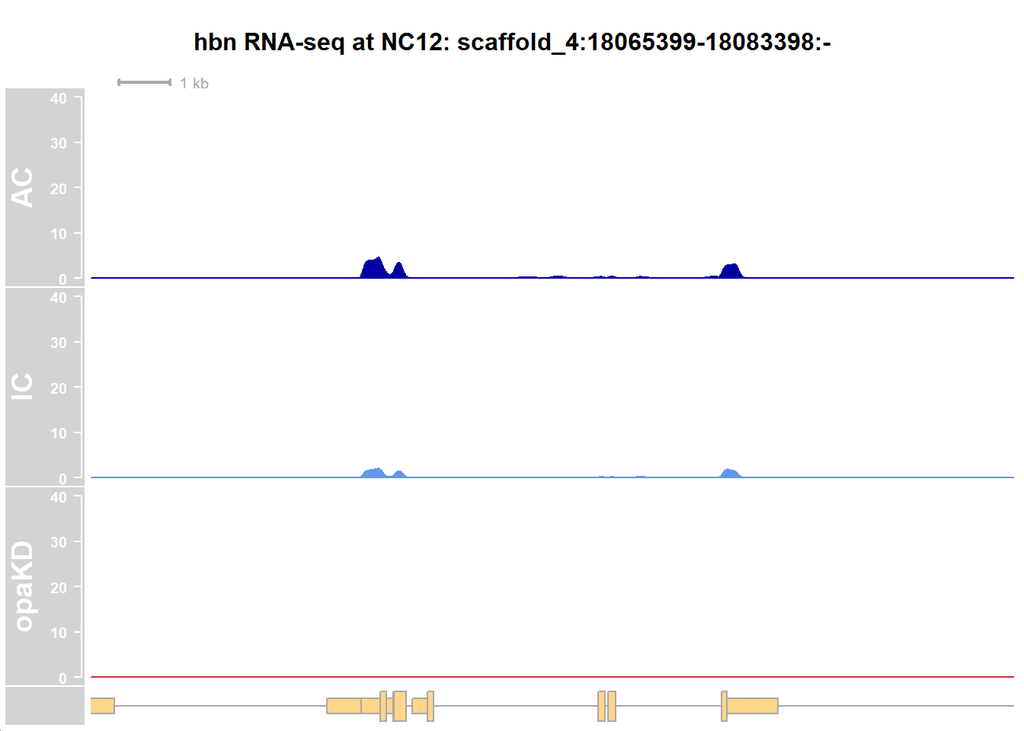

```r
#pdf(file = "./Gviz/hbn-nc12-rna-merged.pdf", width = 8, height = 4.5)

gvizzer(ROI= hbn.locus,
        counts = opakd.nc12.groups.rna.bw,
        view.width = width(hbn.locus),
        nplots = 3,
        shifter = 0,
        title = 'hbn RNA-seq at NC12',
        txstack = "dense",
        scalebar = 1000 ,
        trackcols = c(rep("#0000a2", 1), rep("cornflowerblue", 1), (rep("brown3", 1))),
        plotType = rep("polygon", 3),
        ymin = rep(0, 3),
        ymax = rep(40, 3))
```

```r
#ev.off()
```

###hbn locus NC13

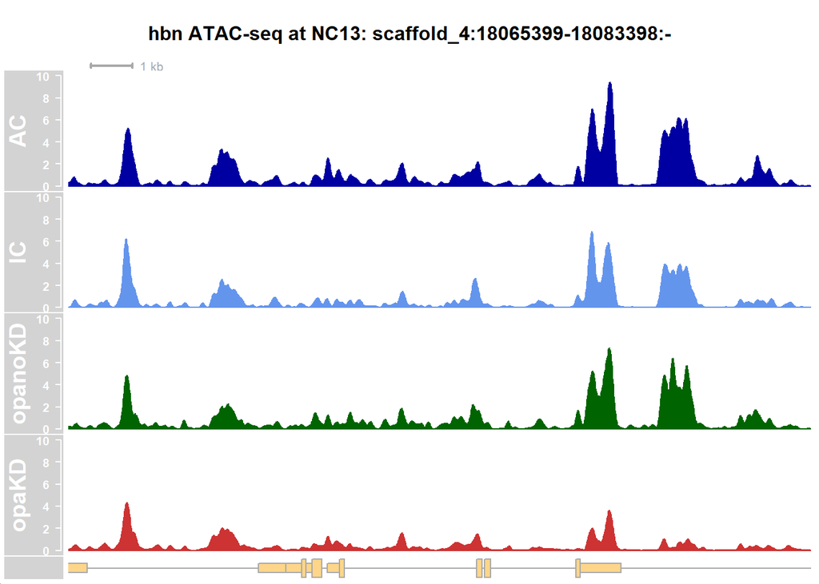

```r
#pdf("./Gviz/hbn-nc13-atac-merged_10cpm.pdf", width = 8,height = 6)


gvizzer(ROI= hbn.locus,
        counts = opakd.nc13.groups.atac.bw,
        view.width = width(hbn.locus),
        nplots = 4,
        shifter = 0,
        title = 'hbn ATAC-seq at NC13',
        txstack = "dense",
        scalebar = 1000 ,
        trackcols = c(rep("#0000a2", 1), rep("cornflowerblue", 1),  rep("darkgreen",1),rep("brown3", 1)),
        plotType = rep("polygon", 4),
        ymin = rep(0,4),
        ymax = rep(10,4))
```

```r
#dev.off()
```

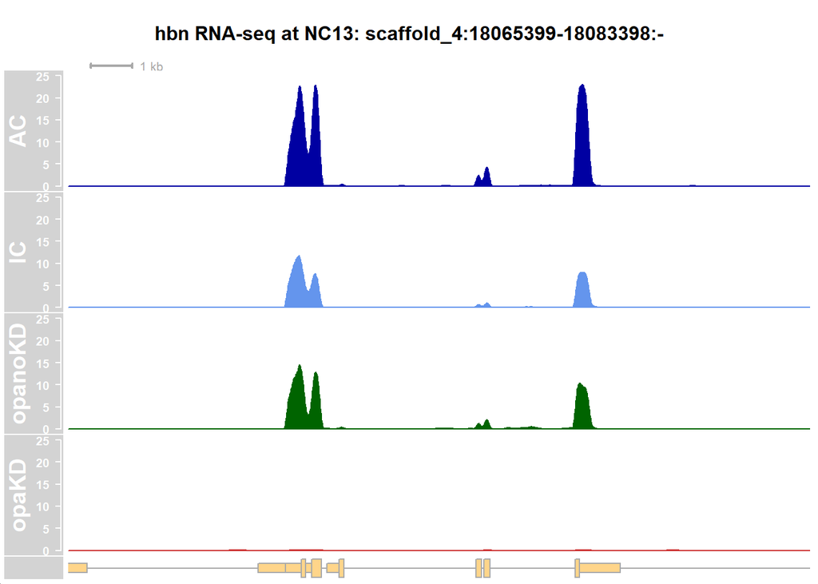

```r
#pdf(file = "./Gviz/hbn-nc13-rna-merged.pdf", width = 8, height = 6)

gvizzer(ROI= hbn.locus,
        counts = opakd.nc13.groups.rna.bw,
        view.width = width(hbn.locus),
        nplots = 4,
        shifter = 0,
        title = 'hbn RNA-seq at NC13',
        txstack = "dense",
        scalebar = 1000 ,
        trackcols = c(rep("#0000a2", 1), rep("cornflowerblue", 1),rep("darkgreen", 1), rep("brown3", 1)),
        plotType = rep("polygon", 4),
        ymin = rep(0,4),
        ymax = rep(25,4))
```

```r
#dev.off()
```

###slp1-3 locus NC12

```r
slp2.locus <- calbi.genes[names(calbi.genes) == "evm.TU.scaffold_5.985"]
slp2.locus <- resize(slp2.locus,width = 80000,fix = "center")
slp2.locus
```

```
## GRanges object with 1 range and 1 metadata column:
##                           seqnames            ranges strand |
##                              <Rle>         <IRanges>  <Rle> |
##   evm.TU.scaffold_5.985 scaffold_5 23560050-23640049      + |
##                                       gene_id
##                                   <character>
##   evm.TU.scaffold_5.985 evm.TU.scaffold_5.985
##   -------
##   seqinfo: 308 sequences from ca6 genome
```

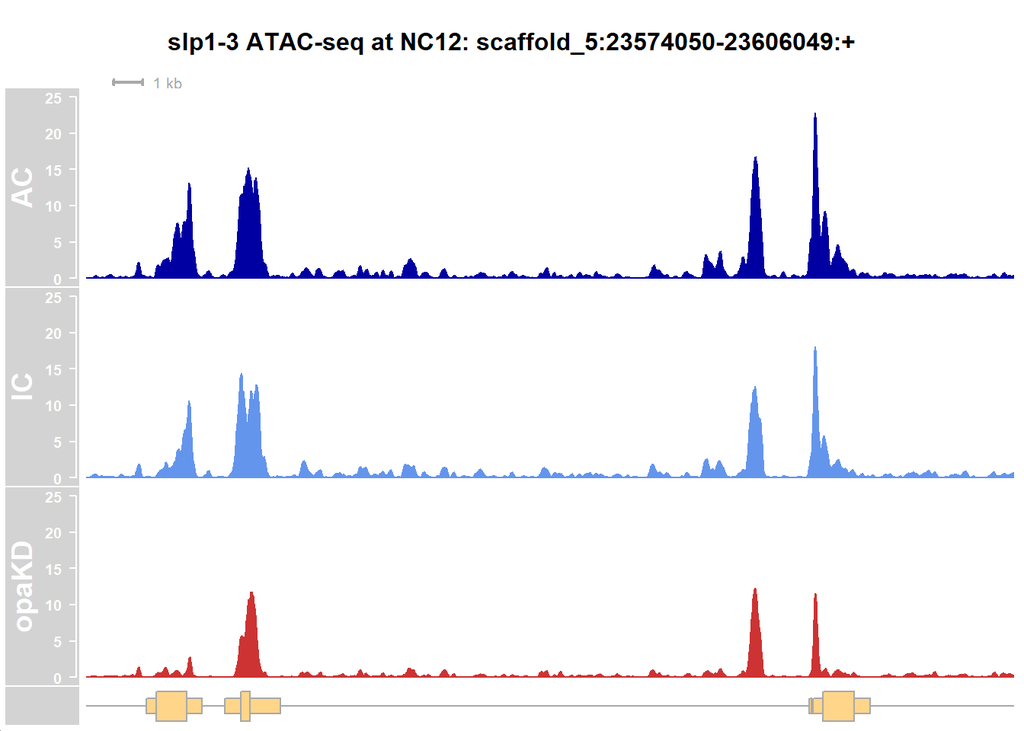

```r
#pdf(file = "./Gviz/slp1-3_NC12_atac.pdf", width = 8,height =4.5 )

gvizzer(ROI= slp2.locus,
        counts = opakd.nc12.groups.atac.bw,
        view.width = width(slp2.locus)-48e+3,
        nplots = 3,
        shifter = -10e+3,
        title = 'slp1-3 ATAC-seq at NC12',
        txstack = "dense",
        scalebar = 1000 ,
        trackcols = c(rep("#0000a2", 1), rep("cornflowerblue", 1), rep("brown3", 1)),
        plotType = rep("polygon", 3),
        ymin = rep(0,3),
        ymax = rep(25,3))
```

```r
#dev.off()
```

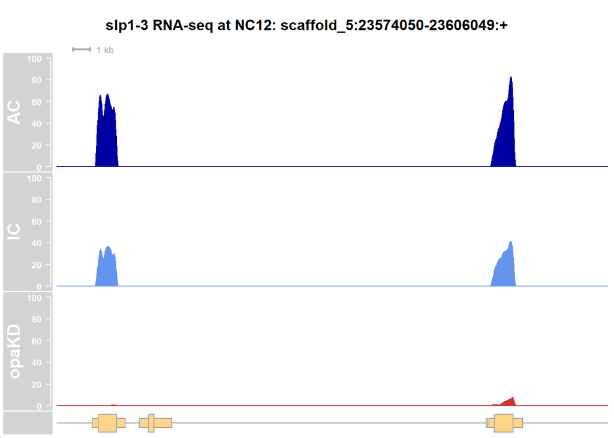

```r
#pdf(file = "./Gviz/slp1-3_NC12_rna.pdf", width = 8,height =4.5 )

gvizzer(ROI= slp2.locus,
        counts = opakd.nc12.groups.rna.bw,
        view.width = width(slp2.locus)-48e+3,
        nplots = 3,
        shifter = -10e+3,
        title = 'slp1-3 RNA-seq at NC12',
        txstack = "dense",
        scalebar = 1000 ,
        trackcols = c(rep("#0000a2", 1), rep("cornflowerblue", 1), rep("brown3", 1)),
        plotType = rep("polygon", 3),
        ymin = rep(0,3),
        ymax = rep(100,3))
```

```r
#dev.off()
```

###slp1-3 locus NC13

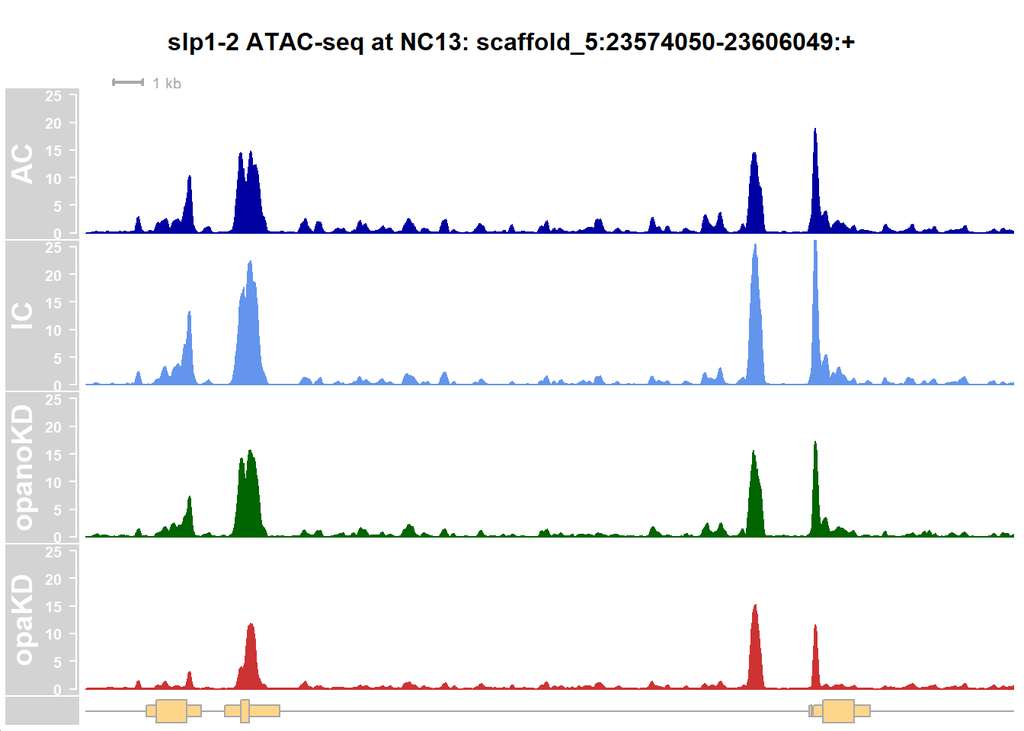

```r
#pdf(file = "./Gviz/slp1-3-nc13-atac-merged.pdf", width = 8,height = 6)

gvizzer(ROI= slp2.locus,
        counts = opakd.nc13.groups.atac.bw,
        view.width = width(slp2.locus)-48e+3,
        nplots = 4,
        shifter = -10e+3,
        title = 'slp1-2 ATAC-seq at NC13',
        txstack = "dense",
        scalebar = 1000 ,
        trackcols = c(rep("#0000a2", 1), rep("cornflowerblue", 1), rep("darkgreen",1),rep("brown3", 1)),
        plotType = rep("polygon", 4),
        ymin = rep(0,4),
        ymax = rep(25,4))
```

```r
#dev.off()
```

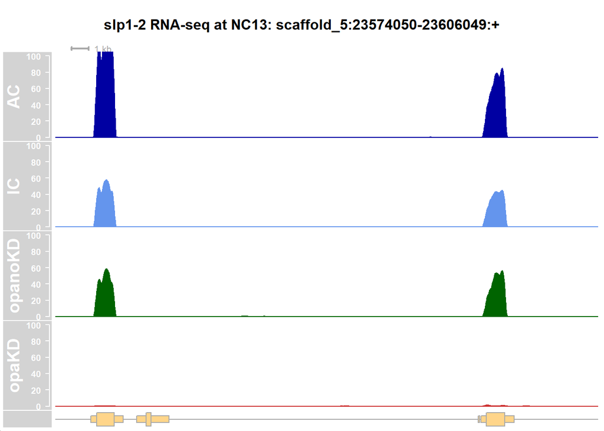

```r
#pdf(file = "./Gviz/slp1-3-nc13-rna-merged.pdf", width = 8,height = 6)

gvizzer(ROI= slp2.locus,
        counts = opakd.nc13.groups.rna.bw,
        view.width = width(slp2.locus)-48e+3,
        nplots = 4,
        shifter = -10e+3,
        title = 'slp1-2 RNA-seq at NC13',
        txstack = "dense",
        scalebar = 1000 ,
        trackcols = c(rep("#0000a2", 1), rep("cornflowerblue", 1), rep("darkgreen",1), rep("brown3", 1)),
        plotType = rep("polygon", 4),
        ymin = rep(0,4),
        ymax = rep(100,4))
```

```r
#dev.off()
```

```r
hb1.locus <- calbi.genes[names(calbi.genes) == "evm.TU.scaffold_7.1783"]
hb1.locus <- resize(hb1.locus,width = 50000,fix = "center")
hb1.locus
```

```
## GRanges object with 1 range and 1 metadata column:
##                            seqnames            ranges strand |
##                               <Rle>         <IRanges>  <Rle> |
##   evm.TU.scaffold_7.1783 scaffold_7 30975983-31025982      + |
##                                         gene_id
##                                     <character>
##   evm.TU.scaffold_7.1783 evm.TU.scaffold_7.1783
##   -------
##   seqinfo: 308 sequences from ca6 genome
```

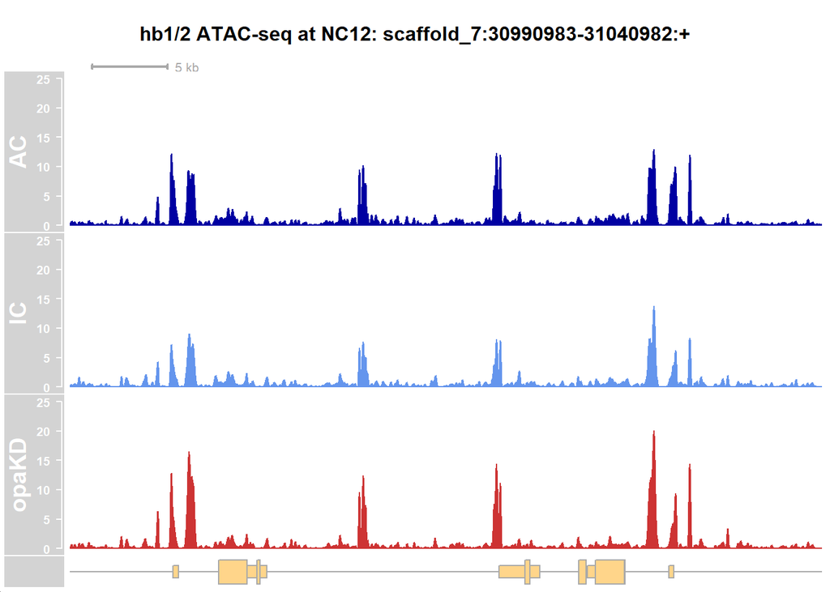

```r
#pdf(file = "./Gviz/hb1-nc12-atac-merged.pdf", width = 8,height = 4.5)

gvizzer(ROI= hb1.locus,
        counts = opakd.nc12.groups.atac.bw,
        view.width = width(hb1.locus),
        nplots = 3,
        shifter = 15e+3,
        title = 'hb1/2 ATAC-seq at NC12',
        txstack = "dense",
        scalebar = 5000 ,
        trackcols = c(rep("#0000a2", 1), rep("cornflowerblue", 1), rep("brown3", 1)),
        plotType = rep("polygon", 3),
        ymin = rep(0,3),
        ymax = rep(25,3))
```

```r
#dev.off()
```

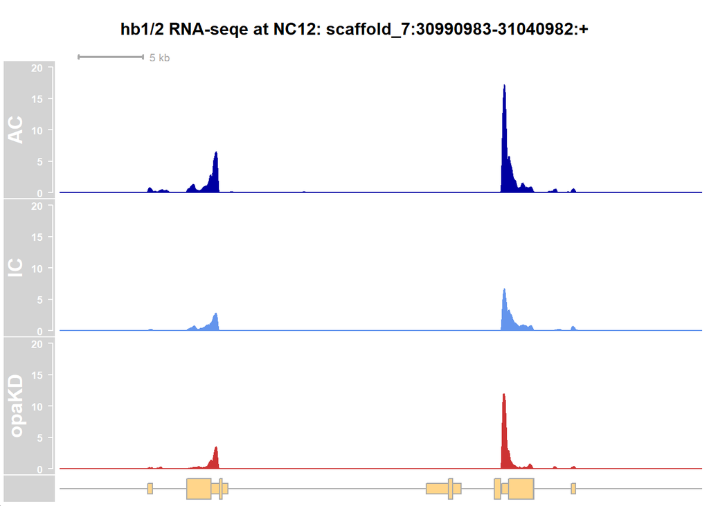

```r
#pdf(file = "./Gviz/hb1-nc12-rna-merged.pdf", width = 8, height = 4.5)


gvizzer(ROI= hb1.locus,
        counts = opakd.nc12.groups.rna.bw,
        view.width = width(hb1.locus),
        nplots = 3,
        shifter = 15e+3,
        title = 'hb1/2 RNA-seqe at NC12',
        txstack = "dense",
        scalebar = 5000 ,
        trackcols = c(rep("#0000a2", 1), rep("cornflowerblue", 1), rep("brown3", 1)),
        plotType = rep("polygon", 3),
        ymin = rep(0,3),
        ymax = rep(20,3))
```

```r
#dev.off()
```

### hb1/2 locus NC13

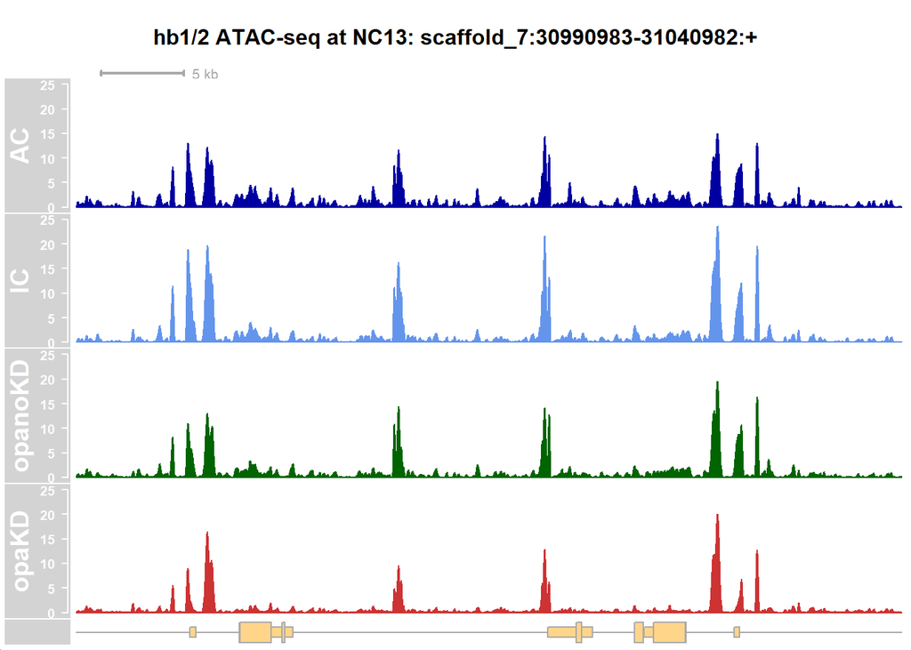

```r
#pdf(file = "./Gviz/hb1-2-nc13-atac-merged.pdf", width = 8,height = 6)

gvizzer(ROI= hb1.locus,
        counts = opakd.nc13.groups.atac.bw,
        view.width = width(hb1.locus),
        nplots = 4,
        shifter = 15e+3,
        title = 'hb1/2 ATAC-seq at NC13',
        txstack = "dense",
        scalebar = 5000 ,
        trackcols = c(rep("#0000a2", 1), rep("cornflowerblue", 1), rep("darkgreen", 1), rep("brown3", 1)),
        plotType = rep("polygon", 4),
        ymin = rep(0,4),
        ymax = rep(25,4))
```

```r
#dev.off()
```

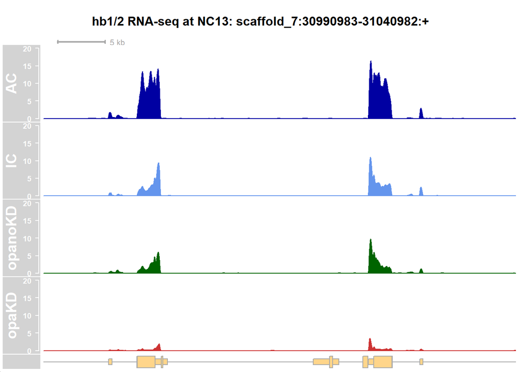

```r
#pdf(file = "./Gviz/hb1-2-nc13-rna-merged.pdf", width = 8, height = 6)


gvizzer(ROI= hb1.locus,
        counts = opakd.nc13.groups.rna.bw,
        view.width = width(hb1.locus),
        nplots = 4,
        shifter = 15e+3,
        title = 'hb1/2 RNA-seq at NC13',
        txstack = "dense",
        scalebar = 5000 ,
        trackcols = c(rep("#0000a2", 1), rep("cornflowerblue", 1),rep("darkgreen", 1), rep("brown3", 1)),
        plotType = rep("polygon", 4),
        ymin = rep(0,4),
        ymax = rep(20,4))
```

```r
#dev.off()
```

### WT Timecourse Expression Gviz

Load in NC2/3(maternal) & NC11-LNC14 RNA-seq data

```r
mtnrl.rna.bw <- GRanges(import("../Processed_Data/Wiggles/WT_TC/mtnrl-rna.bw", format = 'bw'))
mtnrl.rna.bw <- wigsmooth(mtnrl.rna.bw)

nc11.rna.bw <- GRanges(import("../Processed_Data/Wiggles/WT_TC/nc11-rna.bw", format = 'bw'))
nc11.rna.bw <- wigsmooth(nc11.rna.bw)

nc12.rna.bw <- GRanges(import("../Processed_Data/Wiggles/WT_TC/nc12-rna.bw", format = 'bw'))
nc12.rna.bw <- wigsmooth(nc12.rna.bw)

nc13.rna.bw <- GRanges(import("../Processed_Data/Wiggles/WT_TC/nc13-rna.bw", format = 'bw'))
nc13.rna.bw <- wigsmooth(nc13.rna.bw)

nc14.rna.bw <- GRanges(import("../Processed_Data/Wiggles/WT_TC/nc14-rna.bw", format = 'bw'))
nc14.rna.bw <- wigsmooth(nc14.rna.bw)

lnc14.rna.bw <- GRanges(import("../Processed_Data/Wiggles/WT_TC/lnc14-rna.bw", format = 'bw'))
lnc14.rna.bw <- wigsmooth(lnc14.rna.bw)
```

```r
tc.rna.bw <- GRangesList("mtnrl" = mtnrl.rna.bw,
                         "NC11" = nc11.rna.bw,
                         "NC12" = nc12.rna.bw,
                         "NC13" = nc13.rna.bw,
                         "NC14" = nc14.rna.bw,
                         "LNC14" = lnc14.rna.bw)
```

#### zld expression TC

```r
zld.locus <- calbi.genes[names(calbi.genes) == "evm.TU.scaffold_7.1757"]
zld.locus <- resize(zld.locus,width = 12000,fix = "center")
zld.locus
```

```
## GRanges object with 1 range and 1 metadata column:
##                            seqnames            ranges strand |
##                               <Rle>         <IRanges>  <Rle> |
##   evm.TU.scaffold_7.1757 scaffold_7 30815633-30827632      + |
##                                         gene_id
##                                     <character>
##   evm.TU.scaffold_7.1757 evm.TU.scaffold_7.1757
##   -------
##   seqinfo: 308 sequences from ca6 genome
```

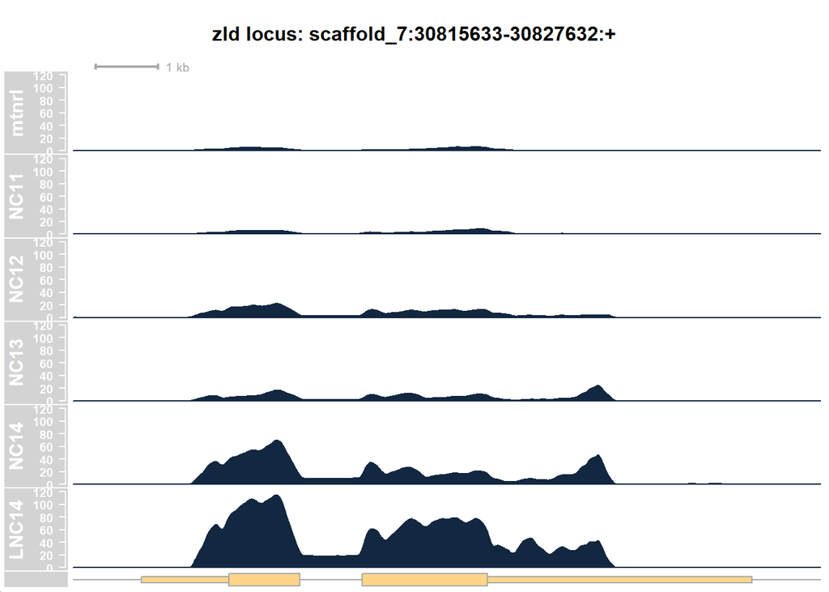

```r
#pdf(fle = "./Gviz/zld-tc-mtrnl-lnc14-rna.pdf", width = 5,height = 10)

gvizzer(ROI= zld.locus,
        counts = tc.rna.bw,
        view.width = width(zld.locus),
        nplots = 6,
        shifter = 0,
        title = 'zld locus',
        txstack = "dense",
        scalebar = 1000 ,
        trackcols = c(rep("#122740",6)),
        plotType = rep("polygon", 6),
        ymin = c(rep(0,6)),
        ymax = c(rep(120,6)))
```

```r
#dev.off()
```

#### hbn expression TC

```r
hbn.locus <- calbi.genes[names(calbi.genes) == "evm.TU.scaffold_4.1647"]
hbn.locus <- resize(hbn.locus,width = 10000,fix = "center")
hbn.locus
```

```
## GRanges object with 1 range and 1 metadata column:
##                            seqnames            ranges strand |
##                               <Rle>         <IRanges>  <Rle> |
##   evm.TU.scaffold_4.1647 scaffold_4 18069399-18079398      - |
##                                         gene_id
##                                     <character>
##   evm.TU.scaffold_4.1647 evm.TU.scaffold_4.1647
##   -------
##   seqinfo: 308 sequences from ca6 genome
```

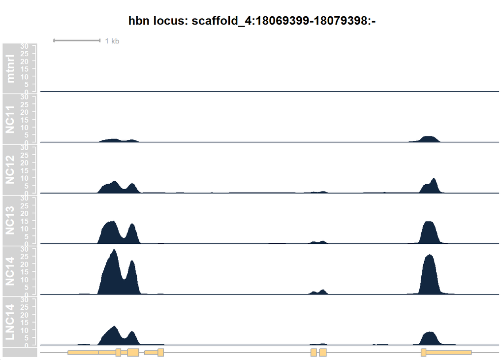

```r
#pdf(file = "./Gviz/hbn-tc-mtrnl-lnc14-rna.pdf", width = 5,height = 10)

gvizzer(ROI= hbn.locus,
        counts = tc.rna.bw,
        view.width = width(hbn.locus),
        nplots = 6,
        shifter = 0,
        title = 'hbn locus',
        txstack = "dense",
        scalebar = 1000 ,
        trackcols = c(rep("#122740",6)),
        plotType = rep("polygon", 6),
        ymin = c(rep(0,6)),
        ymax = c(rep(30,6)))
```

```r
#dev.off()
```

#### slp1 exprssion TC

```r
slp1.locus <- calbi.genes[names(calbi.genes) == "evm.TU.scaffold_5.983"]
slp1.locus <- resize(slp1.locus,width = 10000,fix = "center")
slp1.locus
```

```
## GRanges object with 1 range and 1 metadata column:
##                           seqnames            ranges strand |
##                              <Rle>         <IRanges>  <Rle> |
##   evm.TU.scaffold_5.983 scaffold_5 23572093-23582092      - |
##                                       gene_id
##                                   <character>
##   evm.TU.scaffold_5.983 evm.TU.scaffold_5.983
##   -------
##   seqinfo: 308 sequences from ca6 genome
```

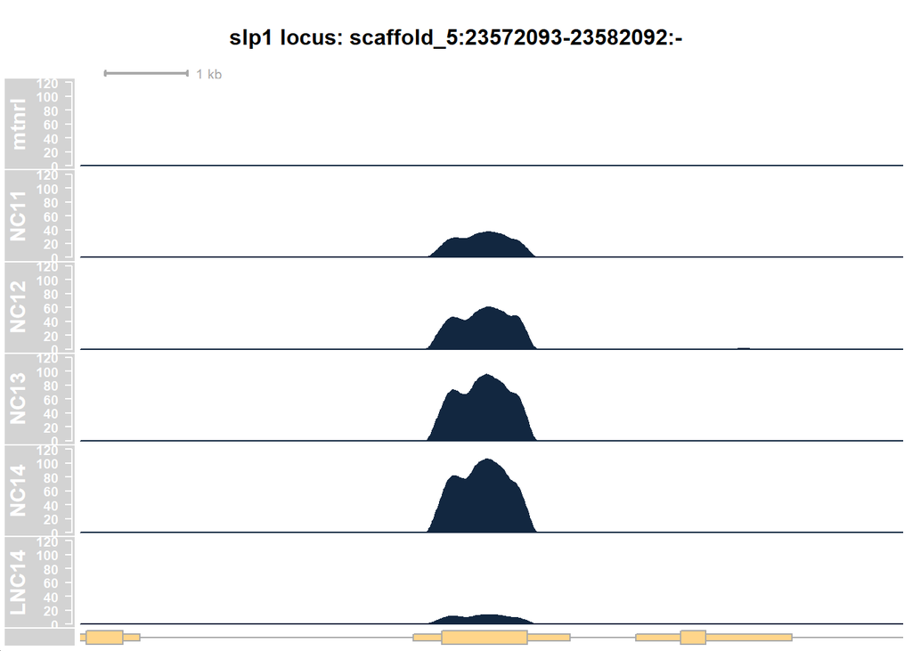

```r
#pdf(file = "./Gviz/slp1-tc-mtrnl-lnc14-rna.pdf", width = 5,height = 10)

gvizzer(ROI= slp1.locus,
        counts = tc.rna.bw,
        view.width = width(slp1.locus),
        nplots = 6,
        shifter = 0,
        title = 'slp1 locus',
        txstack = "dense",
        scalebar = 1000 ,
        trackcols = c(rep("#122740",6)),
        plotType = rep("polygon", 6),
        ymin = c(rep(0,6)),
        ymax = c(rep(120,6)))
```

```r
#dev.off()
```